# Initial DE Analysis

Ken Field

8/24/2019

## DESeq2 Results

The kallisto transcript abundances were used to analyze differential expression between the 4 treatment groups.

SARTools.DESeq2.Kallisto.Transcripts.byGroup/SARTools.DESeq2.Kallisto.Transcripts.byGroup_report.html

## edgeR Results

To confirm that the lower than expected amount of DE transcripts wasn’t a quirk due to DESeq2, I also ran edgeR

The kallisto transcript abundances were used to analyze differential expression between the 4 treatment groups.

SARTools.edgeR.Kallisto.Transcripts.byGroup/SARTools.edgeR.Kallisto.Transcripts.byGroup_report.html

## Initial Summary

DESeq2:

```r
#Number of features down/up and total:
#Test vs Ref                  # down # up # total
#Combination vs Control       0      7    7
#Cort vs Control              1      6    7
#Pregnanedione vs Control     2      1    3
#Cort vs Combination          1      0    1
#Pregnanedione vs Combination 29     11   40
#Pregnanedione vs Cort        26     21   47
```

edgeR:

```r
#Number of features down/up and total:
#Test vs Ref                  # down # up # total
#Combination vs Control       0      3    3
#Cort vs Control              0      2    2
#Pregnanedione vs Control     0      0    0
#Cort vs Combination          0      0    0
#Pregnanedione vs Combination 14     3    17
#Pregnanedione vs Cort        7      4    11
```

There is nothing in the Data Exploration that would indicate that there is a problem with the reads or the analysis. The distribution of transcript abundances are similar in all groups and the fitting of the data to the DESeq2 and edgeR models appears good.

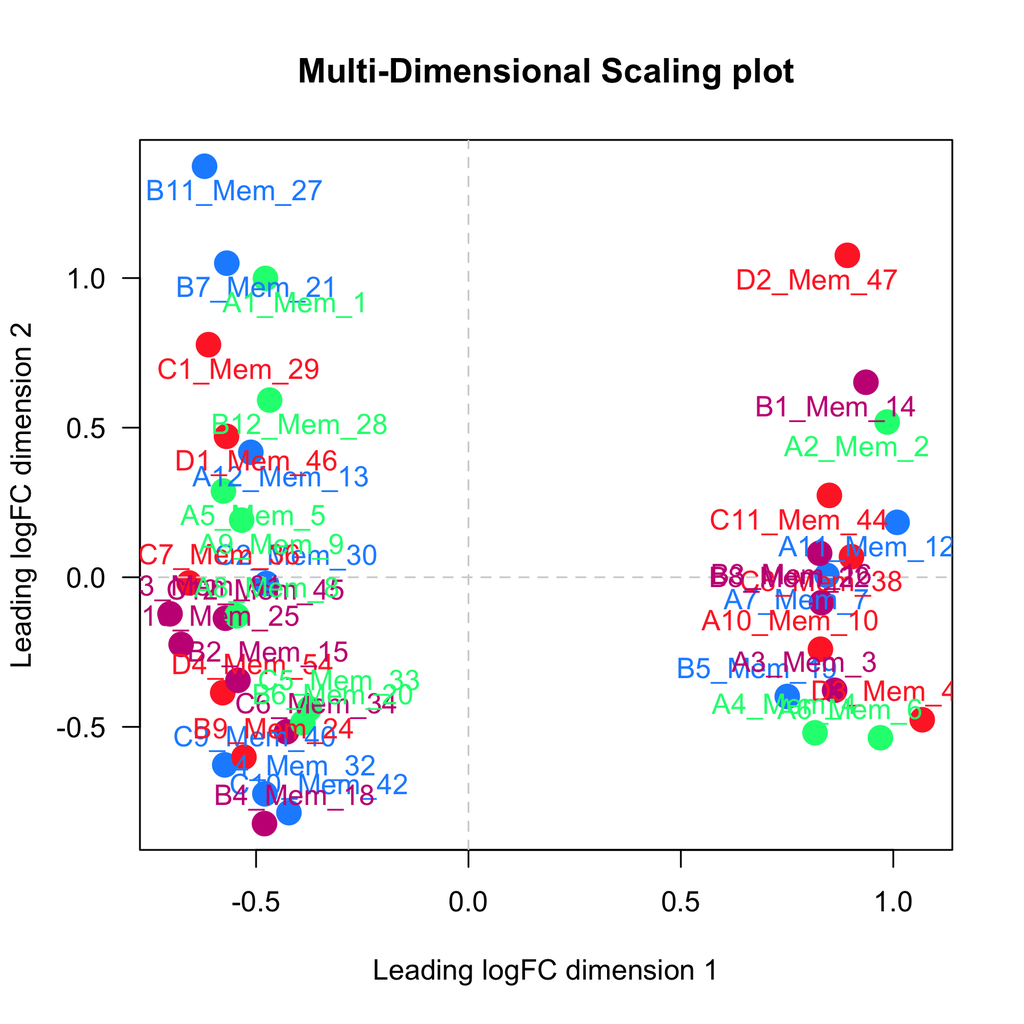

edgeR MDS plot

One possible explanation is that the two groups represent male and female. I will try to confirm this using differential expression of transcripts between the groups.